# Demo 5 (Robinson): Single-cell RNA-seq pipeline

## Cell type annotation

One way to annotate the data (i.e., retrieve the cell-types) can be done by examination of the marker genes previously identified. However, such annotations are hardly reproducible, manual and not scalable to bigger datasets.

We will here see one automatic method of annotation: the **reference-based annotation**. These types of methods assign a label to each cell of a query dataset based on its correlation with a well-curated reference sample where the cell-types are known. One popular tool using this approach is the [`singleR`](https://bioconductor.org/packages/devel/bioc/vignettes/SingleR/inst/doc/SingleR.html) package.

Let’s first load a reference PBMC (blood) dataset:

```r
ref <- BlueprintEncodeData() ## write 'yes' if asked to create a cache directory
```

```
## snapshotDate(): 2021-10-19
```

```
## see ?celldex and browseVignettes('celldex') for documentation
```

```
## loading from cache
```

```
## see ?celldex and browseVignettes('celldex') for documentation
```

```
## loading from cache
```

```r
ref
```

```
## class: SummarizedExperiment
## dim: 19859 259
## metadata(0):
## assays(1): logcounts
## rownames(19859): TSPAN6 TNMD ... LINC00550 GIMAP1-GIMAP5
## rowData names(0):
## colnames(259): mature.neutrophil
##   CD14.positive..CD16.negative.classical.monocyte ...
##   epithelial.cell.of.umbilical.artery.1
##   dermis.lymphatic.vessel.endothelial.cell.1
## colData names(3): label.main label.fine label.ont
```

We can now call the `SingleR` function, which will compute the Spearman rank correlation for each cell in the query against the reference dataset and return the most probable label:

```r
pred <- SingleR(test=pbmc.sce, ref=ref, labels=ref$label.main)
table(pred$labels)
```

```
##
##      B-cells CD4+ T-cells CD8+ T-cells          HSC    Monocytes     NK cells
##          326          540          872            6          643          200
```

We can then inspect the results in a heatmap:

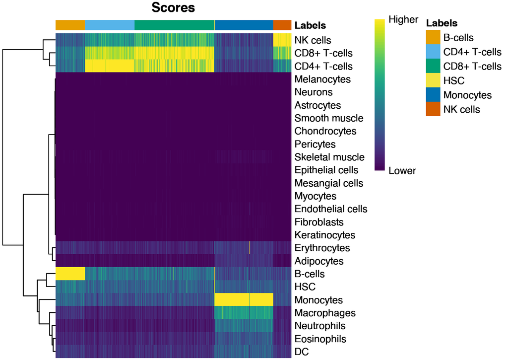

```r
plotScoreHeatmap(pred)
```

We can see that `SingleR` could identify the NK cells, B cells and monocytes with a high confidence. However CD8+ and CD4+ T cells scores are overlapping, which is a common problem in annotation as these two cell-types differentiate quite late in the lymphoid lineage.

We can also visualize the predictions on a TSNE:

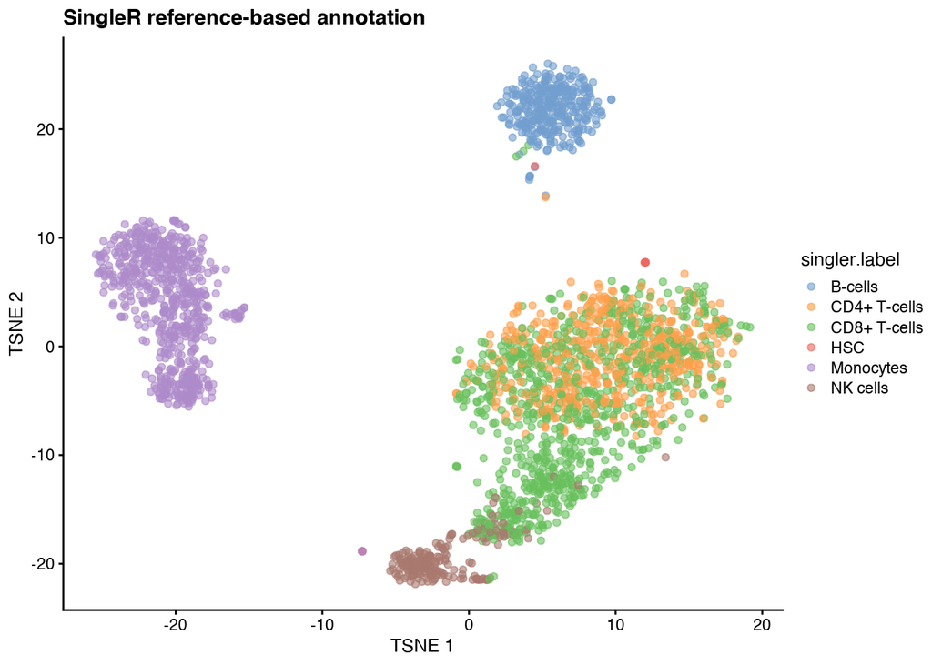

```r
pbmc.sce$singler.label <- pred$labels
plotTSNE(pbmc.sce, colour_by = "singler.label") +
    ggtitle("SingleR reference-based annotation")
```

## Links

- [Seurat](https://satijalab.org/seurat/)
- [Seurat tutorials](https://satijalab.org/seurat/get_started.html)
- [scran](https://bioconductor.org/packages/release/bioc/html/scran.html)
- [scater](https://bioconductor.org/packages/release/bioc/html/scater.html)
- [Hemberg Lab tutorial](https://scrnaseq-course.cog.sanger.ac.uk/website/index.html)